# Lab 4: Resampling

PSTAT 131/231

## Introduction

This lab will show how to perform different resampling techniques. Some of these tasks are quite general and useful in many different areas. In this course, we’ll primarily be using stratified *k*-fold cross-validation, but other techniques can be valuable in different cases.

This chapter will bring [`rsample`](https://www.tidymodels.org/start/resampling/) into view for creating resampled data frames as well as [`yardstick`](https://yardstick.tidymodels.org/) to calculate performance metrics. Lastly, we will also use [`tune`](https://tune.tidymodels.org/) to fit out models within said resamples. We also see a use of [`dials`](https://dials.tidymodels.org/), which are used together with `tune` to select hyperparameter tuning values. All these packages are loaded when we load `tidymodels`.

### Loading Packages

We load `tidymodels` for modeling functions, `ISLR` and `ISLR2` for data sets, and the `tidyverse`.

```r
library(tidymodels)
library(ISLR)
library(ISLR2)
library(tidyverse)
tidymodels_prefer()
```

### Data

We’ll be working with the `Auto` and `Carseats` data sets for this lab.

```r
Auto <- tibble(ISLR::Auto)
Carseats <- tibble(Carseats)
```

#### Activities

- Access the help page for both `Auto` and `Portfolio`. Familiarize yourself with the subject of each data set and the predictor variables.

## The Initial Split

When fitting a model, it is often desired to be able to calculate a performance metric to quantify how well the model fits the data. If a model is evaluated on the data it was fit on, you are quite likely to get over-optimistic results. Therefore, we always split our data into testing and training. This way we can fit the model to data and evaluate it on some other data that is similar.

Splitting of the data is done using random sampling, so it is advised to set a seed before splitting to assure we can reproduce the results. The `initial_split()` function takes a `data.frame` and returns a `rsplit` object. This object contains information about which observations belong to which data set, testing, and training. This is where you would normally set a proportion of data that is used for training and how much is used for evaluation. This is set using the `prop` argument. We also set the `strata` argument. This argument makes sure that both sides of the split have roughly the same distribution for each value of strata. If a numeric variable is passed to `strata`, then it is binned and distributions are matched within bins.

Even when doing another approach such as cross-validation, you **must** perform the initial split. Fitting models to the entire training set would then be a validation set approach, while cross-validation would constitute resampling from the training set.

```r
set.seed(3435)
Auto_split <- initial_split(Auto, strata = mpg, prop = 0.7)
Auto_split
```

```
## <Training/Testing/Total>
## <272/120/392>
```

The testing and training data sets can be materialized using the `testing()` and `training()` functions, respectively:

```r
Auto_train <- training(Auto_split)
Auto_test <- testing(Auto_split)
```

We can use `dim()` to verify that the correct number of observations are now in each data set:

```r
dim(Auto_train)
```

```
## [1] 272   9
```

```r
dim(Auto_test)
```

```
## [1] 120   9
```

#### Activities

- Split the `Carseats` data into training and testing sets, with 80% in training and 20% in testing. Stratify the split on `Sales`.

```r
Carseats_split <- initial_split(Carseats, prop=0.8, strata=Sales)
Carseats_train <- training(Carseats_split)
Carseats_test <- testing(Carseats_split)
```

- Verify that each set has the correct number of observations.

```r
dim(Carseats_train)
```

```
## [1] 319  11
```

```r
dim(Carseats_test)
```

```
## [1] 81 11
```

```r
dim(Carseats_train)/dim(Carseats)
```

```
## [1] 0.7975 1.0000
```

```r
dim(Carseats_test)/dim(Carseats)
```

```
## [1] 0.2025 1.0000
```

## Validation Set Approach

Now that we have a train-test split, to use the validation set approach, let us fit some models **to the entire training set** and evaluate their performance. *Note that this is the approach we’ve been using on the homework and lab assignments thus far.*

Before we move on, it is important to reiterate that you should only use the testing data set **once**! Once you have looked at the performance on the testing data set, you should not modify your models. If you do, you might overfit the model due to data leakage.

Our modeling goal is to predict `mpg` by `horsepower` using a simple linear regression model and a polynomial regression model.

### Linear Model

First, we set up a linear regression specification:

```r
lm_spec <- linear_reg() %>%
  set_mode("regression") %>%
  set_engine("lm")
```

And we fit it like normal. Note that we are fitting it using Auto_train.

```r
lm_fit <- lm_spec %>%
  fit(mpg ~ horsepower, data = Auto_train)
```

We can now use the `augment()` function to extract the predictions and `rmse()` to calculate the root mean squared error. This will be the testing RMSE, since we are evaluating on `Auto_test`.

```r
augment(lm_fit, new_data = Auto_test) %>%
  rmse(truth = mpg, estimate = .pred)
```

```
## # A tibble: 1 × 3
##   .metric .estimator .estimate
##   <chr>   <chr>          <dbl>
## 1 rmse    standard        4.77
```

and we get a RMSE of 4.77. This specific value is going to vary a little depending on what seed number you picked, since the random sampling used in splitting the data set will be slightly different.

Using this framework makes it easy for us to calculate the training RMSE:

```r
augment(lm_fit, new_data = Auto_train) %>%
  rmse(truth = mpg, estimate = .pred)
```

```
## # A tibble: 1 × 3
##   .metric .estimator .estimate
##   <chr>   <chr>          <dbl>
## 1 rmse    standard        4.95
```

Comparing these two values can give us a look into how generalizable the model is to data it hasn’t seen before. We do expect the training RMSE to be lower than the testing RMSE, but if you see a large difference, there is an indication of overfitting or a shift between the training data set and testing data set.

#### Activities

- Fit a linear regression to the `Carseats` data, predicting `Sales`.

```r
lm_fit <- lm_spec %>%
  fit(Sales ~ ., data = Carseats_train)
```

- Calculate the training and testing RMSE for the `Carseats` regression.

```r
print('Training Set:')
```

```
## [1] "Training Set:"
```

```r
augment(lm_fit, new_data = Carseats_train) %>%
  rmse(truth = Sales, estimate = .pred)
```

```
## # A tibble: 1 × 3
##   .metric .estimator .estimate
##   <chr>   <chr>          <dbl>
## 1 rmse    standard       0.980
```

```r
print('Testing Set:')
```

```
## [1] "Testing Set:"
```

```r
augment(lm_fit, new_data = Carseats_test) %>%
  rmse(truth = Sales, estimate = .pred)
```

```
## # A tibble: 1 × 3
##   .metric .estimator .estimate
##   <chr>   <chr>          <dbl>
## 1 rmse    standard        1.12
```

### Polynomial Regression

Next we will fit a polynomial regression model. We can use the linear model specification `lm_spec` to add a preprocessing unit with `recipe()` and `step_poly()` to create the polynomial expansion of `horsepower`. We can combine these two with `workflow()` to create a workflow object.

```r
poly_rec <- recipe(mpg ~ horsepower, data = Auto_train) %>%
  step_poly(horsepower, degree = 2)

poly_wf <- workflow() %>%
  add_recipe(poly_rec) %>%
  add_model(lm_spec)

poly_wf
```

```
## ══ Workflow ════════════════════════════════════════════════════════════════════
## Preprocessor: Recipe
## Model: linear_reg()
##
## ── Preprocessor ────────────────────────────────────────────────────────────────
## 1 Recipe Step
##
## • step_poly()
##
## ── Model ───────────────────────────────────────────────────────────────────────
## Linear Regression Model Specification (regression)
##
## Computational engine: lm
```

We can now fit this model. Again, remember to fit it on the training data set, `Auto_train`.

```r
poly_fit <- fit(poly_wf, data = Auto_train)
```

The testing RMSE is then calculated as:

```r
augment(poly_fit, new_data = Auto_test) %>%
  rmse(truth = mpg, estimate = .pred)
```

```
## # A tibble: 1 × 3
##   .metric .estimator .estimate
##   <chr>   <chr>          <dbl>
## 1 rmse    standard        4.12
```

Which is a bit lower. So it would appear, from this, that the polynomial regression model has a better fit.

#### Activities

- Fit a polynomial regression to the `Carseats` data, predicting `Sales`.

```r
poly_seats_rec <- recipe(Sales ~ Price, data = Carseats_train) %>%
  step_poly(Price, degree = 2)

poly_seats_wf <- workflow() %>%
  add_recipe(poly_seats_rec) %>%
  add_model(lm_spec)

poly_seats_fit <- fit(poly_seats_wf, data = Carseats_train)
```

- Calculate the training and testing RMSE for the `Carseats` regression.

```r
augment(poly_seats_fit, new_data = Carseats_test) %>%
  rmse(truth = Sales, estimate = .pred)
```

```
## # A tibble: 1 × 3
##   .metric .estimator .estimate
##   <chr>   <chr>          <dbl>
## 1 rmse    standard        2.73
```

## *k*-fold Cross-Validation

Earlier, we set `degree = 2` to create a second-degree polynomial regression model. But suppose we want to find the best value of degree that yields the “closest” fit. This is known as hyperparameter tuning, and it is a case where we can use k-Fold Cross-Validation. To use k-Fold Cross-Validation, we will be using the `tune` package, and we need 3 things to get it working:

- A parsnip/workflow object with one or more arguments marked for tuning,
- A `vfold_cv` rsample object of the cross-validation resamples, &
- A tibble denoting the values of hyperparameter values to be explored.

Here, we are doing the hyperparameter tuning on just one parameter, namely the `degree` argument in `step_poly()`, but the same process can be used to tune multiple hyperparameters. Creating a new recipe with `degree = tune()` indicates that we intend for degree to be tuned.

```r
poly_tuned_rec <- recipe(mpg ~ horsepower, data = Auto_train) %>%
  step_poly(horsepower, degree = tune())

poly_tuned_wf <- workflow() %>%
  add_recipe(poly_tuned_rec) %>%
  add_model(lm_spec)
```

This means that would not be able to fit this workflow right now as the value of degree is unspecified, and if we try we get an error:

```r
fit(poly_tuned_wf, data = Auto_train)
```

```
## Error in `recipes::prep()`:
## ! You cannot `prep()` a tuneable recipe. Argument(s) with `tune()`: 'degree'. Do you want to use a tuning function such as `tune_grid()`?
```

The next thing we need to create is the k-Fold data set. This can be done using the `vfold_cv()` function. Note that the function uses `v` instead of `k`, which is the terminology of ISLR. Common choices for k/v are 5 or 10. Here, we use 10 folds.

```r
Auto_folds <- vfold_cv(Auto_train, v = 10)
Auto_folds
```

```
## #  10-fold cross-validation
## # A tibble: 10 × 2
##    splits           id
##    <list>           <chr>
##  1 <split [244/28]> Fold01
##  2 <split [244/28]> Fold02
##  3 <split [245/27]> Fold03
##  4 <split [245/27]> Fold04
##  5 <split [245/27]> Fold05
##  6 <split [245/27]> Fold06
##  7 <split [245/27]> Fold07
##  8 <split [245/27]> Fold08
##  9 <split [245/27]> Fold09
## 10 <split [245/27]> Fold10
```

The result is a tibble of `vfold_splits` which is quite similar to the `rsplit` object we saw earlier.

The last thing we need is a tibble of possible values we want to explore. Each of the tuneable parameters in `tidymodels` has an associated function in the `dials` package. We need to use the `degree()` function here, and we extend the range to have a max of 10. This `dials` function is then passed to `grid_regular()` to create a regular grid of values.

```r
degree_grid <- grid_regular(degree(range = c(1, 10)), levels = 10)
degree_grid
```

```
## # A tibble: 10 × 1
##    degree
##     <dbl>
##  1      1
##  2      2
##  3      3
##  4      4
##  5      5
##  6      6
##  7      7
##  8      8
##  9      9
## 10     10
```

Using `grid_regular()` is a little overkill for this application, with only one parameter, but once you have multiple parameters you want to tune, the `grid` functions are very helpful.

Now that all the necessary objects have been created, we can pass them to `tune_grid()`, which will fit the models within each fold for each value specified in `degree_grid`.

```r
tune_res <- tune_grid(
  object = poly_tuned_wf,
  resamples = Auto_folds,
  grid = degree_grid
)
```

It can be helpful to add `control = control_grid(verbose = TRUE)`; this will print out the progress, which can be especially helpful when the models take a while to fit. `tune_res` by itself isn’t easily readable. Luckily, `tune` provides a handful of helper functions.

`autoplot()` gives a visual overview of the performance of different hyperparameter pairs:

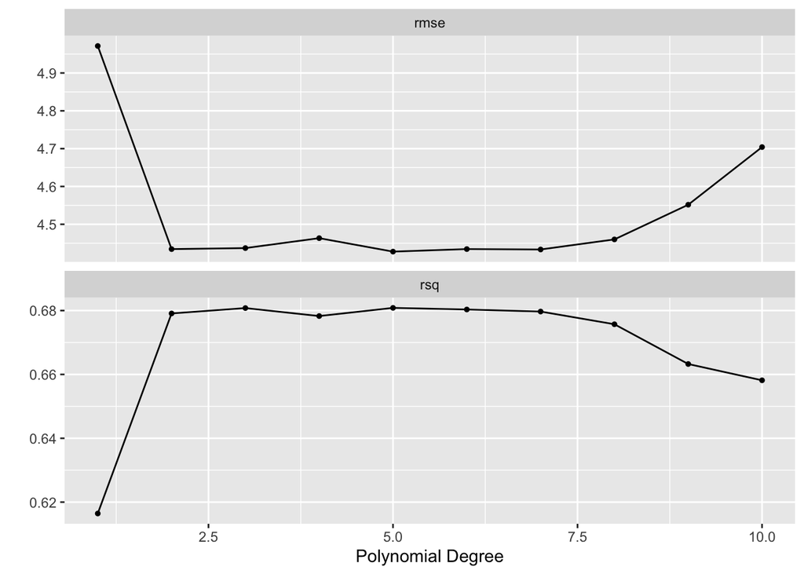

```r
autoplot(tune_res)
```

It appears that the biggest jump in performance comes from going to `degree = 2`. Afterward, there might be a little bit of improvement, but it isn’t as obvious.

The number used for plotting can be extracted directly with `collect_metrics()`. We also get an estimate of the standard error of the performance metric. We get this since we have 10 different estimates, one for each fold.

```r
collect_metrics(tune_res)
```

```
## # A tibble: 20 × 7
##    degree .metric .estimator  mean     n std_err .config
##     <dbl> <chr>   <chr>      <dbl> <int>   <dbl> <chr>
##  1      1 rmse    standard   4.97     10  0.170  Preprocessor01_Model1
##  2      1 rsq     standard   0.616    10  0.0291 Preprocessor01_Model1
##  3      2 rmse    standard   4.43     10  0.240  Preprocessor02_Model1
##  4      2 rsq     standard   0.679    10  0.0348 Preprocessor02_Model1
##  5      3 rmse    standard   4.44     10  0.247  Preprocessor03_Model1
##  6      3 rsq     standard   0.681    10  0.0357 Preprocessor03_Model1
##  7      4 rmse    standard   4.46     10  0.244  Preprocessor04_Model1
##  8      4 rsq     standard   0.678    10  0.0357 Preprocessor04_Model1
##  9      5 rmse    standard   4.43     10  0.238  Preprocessor05_Model1
## 10      5 rsq     standard   0.681    10  0.0360 Preprocessor05_Model1
## 11      6 rmse    standard   4.43     10  0.233  Preprocessor06_Model1
## 12      6 rsq     standard   0.680    10  0.0358 Preprocessor06_Model1
## 13      7 rmse    standard   4.43     10  0.233  Preprocessor07_Model1
## 14      7 rsq     standard   0.680    10  0.0353 Preprocessor07_Model1
## 15      8 rmse    standard   4.46     10  0.233  Preprocessor08_Model1
## 16      8 rsq     standard   0.676    10  0.0356 Preprocessor08_Model1
## 17      9 rmse    standard   4.55     10  0.206  Preprocessor09_Model1
## 18      9 rsq     standard   0.663    10  0.0341 Preprocessor09_Model1
## 19     10 rmse    standard   4.70     10  0.254  Preprocessor10_Model1
## 20     10 rsq     standard   0.658    10  0.0354 Preprocessor10_Model1
```

You can also use `show_best()` to only show the best performing models:

```r
show_best(tune_res, metric = "rmse")
```

```
## # A tibble: 5 × 7
##   degree .metric .estimator  mean     n std_err .config
##    <dbl> <chr>   <chr>      <dbl> <int>   <dbl> <chr>
## 1      5 rmse    standard    4.43    10   0.238 Preprocessor05_Model1
## 2      7 rmse    standard    4.43    10   0.233 Preprocessor07_Model1
## 3      2 rmse    standard    4.43    10   0.240 Preprocessor02_Model1
## 4      6 rmse    standard    4.43    10   0.233 Preprocessor06_Model1
## 5      3 rmse    standard    4.44    10   0.247 Preprocessor03_Model1
```

We did see that the performance plateaued after `degree = 2`. There are a couple of functions to select models by more sophisticated rules, `select_by_one_std_err()` and `select_by_pct_loss()`. Here, we use `select_by_one_std_err()` which selects the most simple model that is within one standard error of the numerically optimal results. We need to specify `degree` to tell `select_by_one_std_err()` which direction is more simple.

You want to

- use desc(you_model_parameter) if larger values lead to a simpler model;
- use you_model_parameter if smaller values lead to a simpler model.

Lower polynomials models are simpler, so we ditch `desc()`.

```r
select_by_one_std_err(tune_res, degree, metric = "rmse")
```

```
## # A tibble: 1 × 9
##   degree .metric .estimator  mean     n std_err .config             .best .bound
##    <dbl> <chr>   <chr>      <dbl> <int>   <dbl> <chr>               <dbl>  <dbl>
## 1      2 rmse    standard    4.43    10   0.240 Preprocessor02_Mod…  4.43   4.67
```

This selected `degree = 2`. We will use this value, since using simpler models sometimes can be very beneficial – especially if we want to explain what happens in it.

```r
best_degree <- select_by_one_std_err(tune_res, degree, metric = "rmse")
```

```r
final_wf <- finalize_workflow(poly_wf, best_degree)

final_wf
```

```
## ══ Workflow ════════════════════════════════════════════════════════════════════
## Preprocessor: Recipe
## Model: linear_reg()
##
## ── Preprocessor ────────────────────────────────────────────────────────────────
## 1 Recipe Step
##
## • step_poly()
##
## ── Model ───────────────────────────────────────────────────────────────────────
## Linear Regression Model Specification (regression)
##
## Computational engine: lm
```

This workflow can now be fitted. And we want to make sure we fit it on the full training data set.

```r
final_fit <- fit(final_wf, Auto_train)

final_fit
```

```
## ══ Workflow [trained] ══════════════════════════════════════════════════════════
## Preprocessor: Recipe
## Model: linear_reg()
##
## ── Preprocessor ────────────────────────────────────────────────────────────────
## 1 Recipe Step
##
## • step_poly()
##
## ── Model ───────────────────────────────────────────────────────────────────────
##
## Call:
## stats::lm(formula = ..y ~ ., data = data)
##
## Coefficients:
##       (Intercept)  horsepower_poly_1  horsepower_poly_2
##             23.37             -99.93              35.56
```

Finally, we assess its accuracy on the testing set:

```r
augment(final_fit, new_data = Auto_test) %>%
  rmse(truth = mpg, estimate = .pred)
```

```
## # A tibble: 1 × 3
##   .metric .estimator .estimate
##   <chr>   <chr>          <dbl>
## 1 rmse    standard        4.12
```

#### Activities

- Repeat all these steps on the `Carseats` data.

[figure not shown]

```r
# Starting with Building the tune() Recipe
seats_tuned_rec <- recipe(Sales ~ Education, data = Carseats_train) %>%
  step_poly(Education, degree = tune())

# Seats Workflow
seats_tuned_wf <- workflow() %>%
  add_recipe(seats_tuned_rec) %>%
  add_model(lm_spec)

# K-Folds
Seats_folds <- vfold_cv(Carseats_train, v = 10)

# Grid
seats_degree_grid <- grid_regular(degree(range = c(1, 10)), levels = 10)

# Tuning the Grid
seats_tune_res <- tune_grid(
  object = seats_tuned_wf,
  resamples = Seats_folds,
  grid = seats_degree_grid
)

# Plotting to Find the Best Degree
autoplot(seats_tune_res)
```

```r
# Choosing the Best Degree (Every Possible Predictor has a Best Degree of 1)
best_degree <- select_by_one_std_err(seats_tune_res, degree, metric = "rmse")
best_degree
```

```
## # A tibble: 1 × 9
##   degree .metric .estimator  mean     n std_err .config             .best .bound
##    <dbl> <chr>   <chr>      <dbl> <int>   <dbl> <chr>               <dbl>  <dbl>
## 1      1 rmse    standard    2.75    10   0.120 Preprocessor01_Mod…  2.75   2.87
```

```r
# Final Seats Workflow
seats_final_wf <- finalize_workflow(poly_seats_wf, best_degree)

# Final Seats Fit
seats_final_fit <- fit(seats_final_wf, Carseats_train)

# Accuracy
augment(seats_final_fit, new_data = Carseats_test) %>%
  rmse(truth=Sales, estimate=.pred)
```

```
## # A tibble: 1 × 3
##   .metric .estimator .estimate
##   <chr>   <chr>          <dbl>
## 1 rmse    standard        2.73
```

- Which `degree` value results in the best-fitting model for `Carseats`?

In this case, and in every case, the best `degree` value to fit `Education` to `Sales` is 1.

## Bootstrap

This section illustrates the use of the bootstrap in the simple Section 5.2 of ISLR, as well as on an example involving estimating the accuracy of the linear regression model on the `Auto` data set.

In this example, we want to study the variability of the slope and intercept estimate of the linear regression model. First, we create some bootstraps of the data. Then we create a function that takes a split and returns some values. This function will return a tibble for each bootstrap.

```r
Auto_boots <- bootstraps(Auto)

boot.fn <- function(split) {
  lm_fit <- lm_spec %>% fit(mpg ~ horsepower, data = analysis(split))
  tidy(lm_fit)
}
```

Then we use `mutate()` and `map()` to apply the function to each of the bootstraps:

```r
boot_res <- Auto_boots %>%
  mutate(models = map(splits, boot.fn))
```

And we can now `unnest()` and use `group_by()` and `summarise()` to get an estimate of the variability of the slope and intercept in this linear regression model.

```r
boot_res %>%
  unnest(cols = c(models)) %>%
  group_by(term) %>%
  summarise(mean = mean(estimate),
            sd = sd(estimate))
```

```
## # A tibble: 2 × 3
##   term          mean      sd
##   <chr>        <dbl>   <dbl>
## 1 (Intercept) 40.0   1.02
## 2 horsepower  -0.159 0.00902
```

#### Activities

- Repeat this on the `Carseats` data.

```r
# Function Creation
Seats_boots <- bootstraps(Carseats)

seats_boot.fn <- function(split) {
  lm_fit <- lm_spec %>% fit(Price ~ Education, data = analysis(split))
  tidy(lm_fit)
}

# Applying the Function to Bootstraps
seats_boot_res <- Seats_boots %>%
  mutate(models = map(splits, seats_boot.fn))

# Estimating Slope Variability and Intercept
seats_boot_res %>%
  unnest(cols = c(models)) %>%
  group_by(term) %>%
  summarise(mean = mean(estimate),
            sd = sd(estimate))
```

```
## # A tibble: 2 × 3
##   term            mean    sd
##   <chr>          <dbl> <dbl>
## 1 (Intercept) 116.     4.82
## 2 Education     0.0145 0.348
```

## Resources

The free book [Tidy Modeling with R](https://www.tmwr.org/) is strongly recommended.

## Source

Several parts of this lab come directly from the [“ISLR Tidymodels Labs”](https://emilhvitfeldt.github.io/ISLR-tidymodels-labs/classification.html). Credit to Emil Hvitfeldt for writing and maintaining the open-source book.